# Analysis of Gun Deaths in America

Geophrey O. Odero

### Description

This report will study the nature of gun deaths in America for the year 2012. The data for this study is from the website *FiveThirtyEight* (explored the more than 33,000 annual gun deaths in America and what it would take to bring that number down). I will study the proportions of different gun deaths by gender and race.

*Source of data: FiveThirtyEight - “Gun Deaths in America”. Year 2012 to 2014*.

### Analysis

*Figure 1. Bar plots with proportion of sample of 33563 Americans in* *annual gun deaths for different intent classifications.*

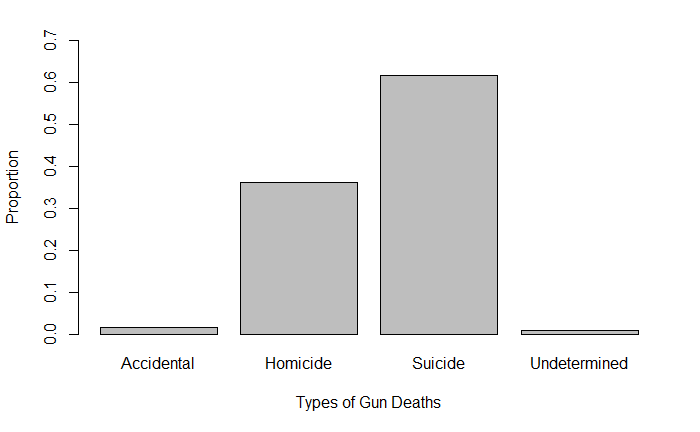

The sample consists of 1.63% in the Accidental gun deaths category, 36.03% in the Homicide gun deaths category, 61.57% Suicide gun deaths category, and 0.762% in the Undetermined gun deaths category.

*Figure 2. Bar plots with percent of each type of gun death category within ethnic groups.*

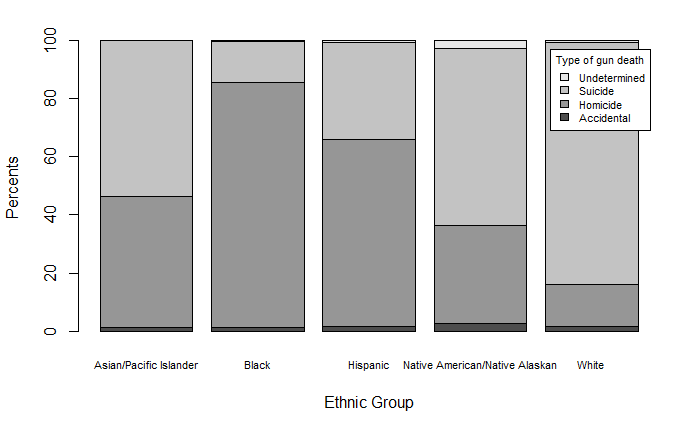

*Table 2. Percent of each type of gun death type within each of five ethnic* *groups.*

```
               Asian/Pacific Islander Black Hispanic Native American/Native Alaskan
  Accidental                     1.10  1.32     1.57                           2.58
  Homicide                      45.25 84.02    64.39                          33.87
  Suicide                       53.42 14.20    33.42                          60.65
  Undetermined                   0.22  0.47     0.62                           2.90

               White
  Accidental    1.75
  Homicide     14.39
  Suicide      82.99
  Undetermined  0.87
```

Table 2 provides the percentages of each type of gun death category within each ethnic group. It is apparent that there is a relationship between type of gun death and ethnicity. A relatively low percentage of accidental gun deaths is observed in all ethnic categories. The percentages of suicide gun deaths in the White ethnic group is substantially higher than for other ethnic groups, whereas the percentages of Homicide gun deaths in the Black ethnic group is substantially higher compared to other ethnic groups.

*Figure 3. Bar plots with proportion of sample of 33563 Americans* *annual gun deaths for different gender classifications.*

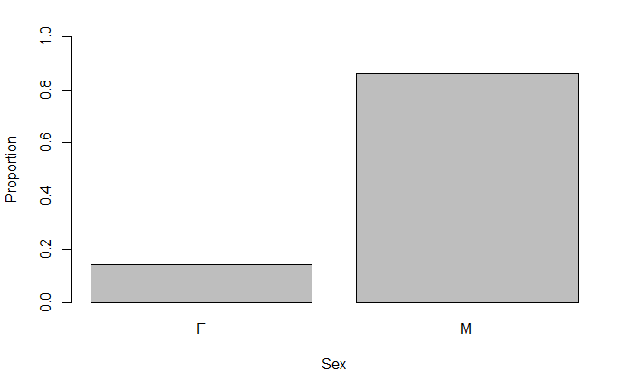

The sample consists of 14.08% gun deaths in females, and 85.92% gun deaths males.

*Figure 4. Bar plots with percent of each type of gun death category within gender groups.*.

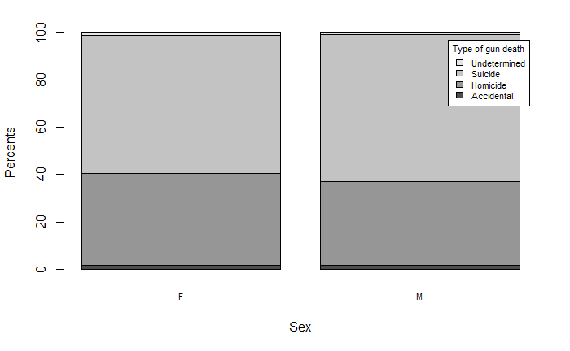

*Table 4. Percent of each type of gun death type within each of two sex* *groups.*

```
                   F     M
  Accidental    1.54  1.65
  Homicide     39.01 35.54
  Suicide      58.33 62.11
  Undetermined  1.12  0.70
```

Table 4 provides the percentages of each gun death category within each sex (gender) group. It is apparent that there is a relationship been gun death category and sex. A relatively low percentage of males and females gun deaths are undetermined. There is relatively higher percentage of gun deaths attributed to suicide in both males and females.

### Conclusions

I examined the proportions of different types of guns deaths, race, and sex. The result of the analysis showed that there is a small percentage of gun deaths in females (14.08%) and a lager percentage of gun deaths(85.92%) in males. The results also show that about 1.63% gun deaths were accidental, 36.03% were due homicide, 61.57% were due suicide, and 0.762% were undetermined.

For two secondary questions; first, I looked at the relationship of type of gun death to ethnic groups, finding that there is a clear relationship. A relatively low percentage of accidental gun deaths are in all ethnic categories. The percentages of suicide gun deaths in the White ethnic group is substantially higher compared to other ethnic groups, whereas the percentages of Homicide gun deaths in the Black ethnic group is substantially higher compared other ethnic groups. Second, I looked at each gun death category within each sex (gender) group. It is apparent that there is a relationship of gun death category and sex. A relatively low percentage of males and females gun deaths are undetermined. There is relatively higher percentage of gun deaths attributed to suicide in both males and females.

##End of report

### Gun Deaths 2019

**Question #3). Making changes to *CDC_parser.R* to extract 2019 data**.

*Data extracted successfully*.

**Question #4). Install two packages: *tidyverse* and *magrittr***

*tidyverse* and *magrittr* installed successfully.

**Question #5). Run the script**

*Script run successfully*.

**Question #6). Analysis of 2019 data**

### Analysis

*Figure 1. Bar plots with proportion of sample of 39709 Americans* *annual gun deaths for different intent classifications.*

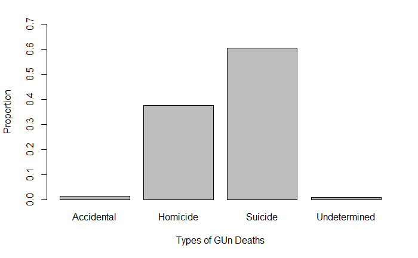

The sample consists of 1.22% in the Accidental gun deaths category, 37.57% in the Homicide gun deaths category, 60.3% Suicide gun deaths category, and 0.87% in the Undetermined gun deaths category.

*Figure 2. Bar plots with percent of each type of gun death category within ethnic groups.*.

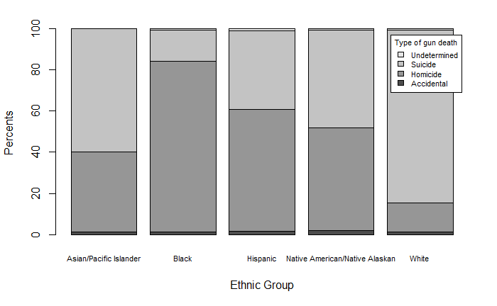

*Table 2. Percent of each type of gun death type within each of five ethnic* *groups.*

```
               Asian/Pacific Islander Black Hispanic Native American/Native Alaskan
  Accidental                     1.40  1.11     1.48                           1.81
  Homicide                      38.85 82.85    59.42                          50.00
  Suicide                       59.59 15.29    37.96                          47.41
  Undetermined                   0.16  0.75     1.14                           0.78

               White
  Accidental    1.21
  Homicide     14.22
  Suicide      83.66
  Undetermined  0.90
```

Table 2 provides the percentages of each type of gun death category within each ethnic group. It is apparent that there is a relationship between type of gun death and ethnicity. A relatively low percentage of accidental gun deaths is observed in all ethnic categories. The percentages of suicide gun deaths in the White ethnic group is substantially higher compared to other ethnic groups, whereas the percentages of Homicide gun deaths in the Black ethnic group is substantially higher compared to other ethnic groups.

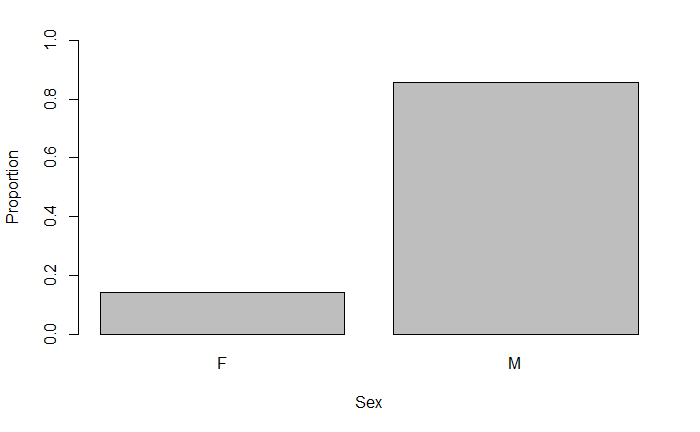

The sample consists of 14.27% gun deaths in females, and 85.73% gun deaths males.

*Figure 4. Bar plots with percent of each type of gun death category within gender groups.*

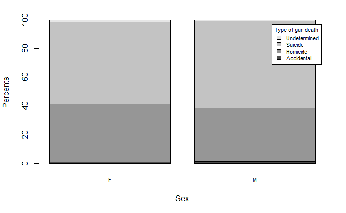

*Table 4. Percent of each type of gun death type within each of two sex* *groups.*

```
                   F     M
  Accidental    0.88  1.28
  Homicide     40.68 37.05
  Suicide      56.86 60.91
  Undetermined  1.57  0.76
```

Table 4 provides the percentages of each gun death category within each sex (gender) group. It is apparent that there is a relationship between gun death category and sex. A relatively low percentage of males and females gun deaths are accidental. There is relatively higher percentage of gun deaths attributed to suicide in both males and females.

*Question#7.) For each of the variables of interest, compare proportions for the two years (2012 and 2019) with graphs and descriptive statistics.*

*Table 5. Proportion of each type of gun death type within each of the gun type groups* *groups.*

```
                 2012   2019
  Accidental   0.0075 0.0066
  Homicide     0.1651 0.2035
  Suicide      0.2821 0.3269
  Undetermined 0.0035 0.0047
```

*Figure 5. Bar plots with proportion of each type of gun death category for 2012 and 2019.*

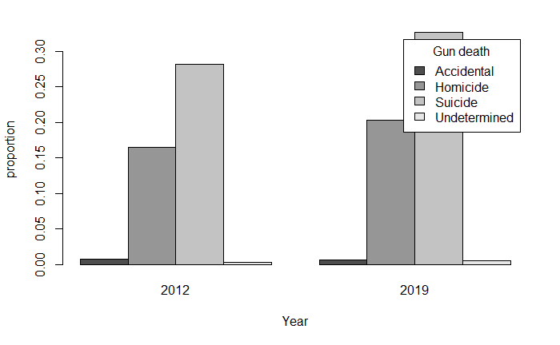

From Table 5 and Figure 5, there is no significant difference in the proportions of type of gun deaths for the years 2012 and 2019. However, there is a slight increase in proportion of gun deaths attributed to Homicide and Suicide from 2012 to 2019.

*Table 6. Proportion of each racial group for 2012 and 2019 gun deaths*

```
                                  2012  2019
  Asian/Pacific Islander         0.006 0.009
  Black                          0.108 0.142
  Hispanic                       0.042 0.055
  Native American/Native Alaskan 0.004 0.005
  White                          0.297 0.330
```

*Figure 6. Bar plots with proportion of each racial group gun deaths for 2012 and 2019.*

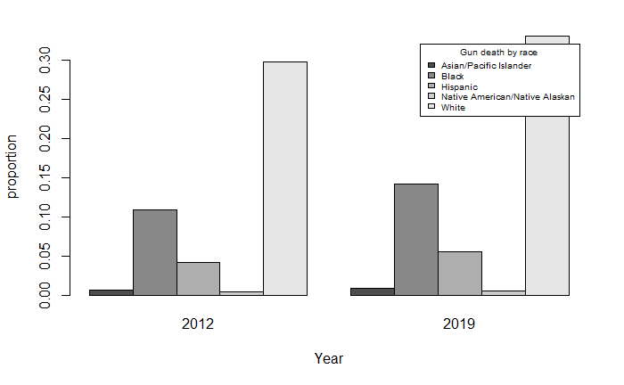

From Table 6 and Figure 6, there is no significant difference in the proportions of gun deaths for the different racial groups in both years. However, the White ethnic group has a significantly high proportion of gun deaths compared to all other racial groups.

*Table 7. Proportion of each sex group for 2012 and 2019 gun deaths*

```
     2012  2019
  F 0.064 0.077
  M 0.394 0.465
```

*Figure 7. Bar plots with proportion of each sex group gun deaths for 2012 and 2019.*

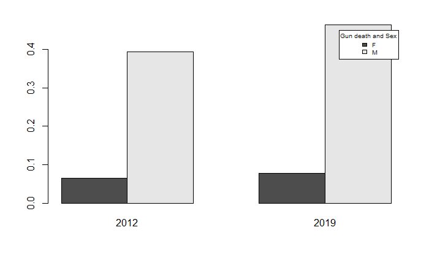